# FEATURISATION & MODEL TUNING

```python
# • DOMAIN: Semiconductor manufacturing process

# • CONTEXT: A complex modern semiconductor manufacturing process is normally under constant surveillance via the monitoring of
# signals/variables collected from sensors and or process measurement points. However, not all of these signals are equally valuable in a
# specific monitoring system. The measured signals contain a combination of useful information, irrelevant information as well as noise.
# Engineers typically have a much larger number of signals than are actually required. If we consider each type of signal as a feature, then
# feature selection may be applied to identify the most relevant signals. The Process Engineers may then use these signals to determine key
# factors contributing to yield excursions downstream in the process. This will enable an increase in process throughput, decreased time to
# learning and reduce the per unit production costs. These signals can be used as features to predict the yield type. And by analysing and
# trying out different combinations of features, essential signals that are impacting the yield type can be identified.
# • DATA DESCRIPTION: sensor-data.csv : (1567, 592)
# The data consists of 1567 datapoints each with 591 features.
# The dataset presented in this case represents a selection of such features where each example represents a single production entity with
# associated measured features and the labels represent a simple pass/fail yield for in house line testing.
# Target column “ –1” corresponds to a pass and “1” corresponds to a fail
# and the data time stamp is for that specific test point.

# • PROJECT OBJECTIVE: We will build a classifier to predict the Pass/Fail yield of a particular process entity and analyse whether all the
# features are required to build the model or not.
```

# Steps and tasks: [ Total Score: 60 points]

```python
#1. Import and understand the data. [5 Marks]
#A. Import ‘signal-data.csv’ as DataFrame. [2 Marks]
#B. Print 5 point summary and share at least 2 observations. [3 Marks]
```

```python
# Import required libraries

import warnings
import pandas as pd
import numpy as np
import matplotlib.pyplot as plt
%matplotlib inline
import seaborn as sns
from scipy.stats import zscore
```

```python
# suppress display of warnings
warnings.filterwarnings('ignore')
```

```python
from google.colab import drive
drive.mount('/content/drive')
```

```python
df_signal=pd.read_csv('/content/drive/MyDrive/AIML/FMT/signal-data.csv')
```

```python
#df_signal=pd.read_csv("signal-data.csv")
```

```python
df_signal.head()
```

|  | Time | 0 | 1 | 2 | 3 | 4 | 5 | 6 | 7 | 8 | ... | 581 | 582 | 583 | 584 | 585 | 586 | 587 | 588 | 589 | Pass/Fail |
| --- | --- | --- | --- | --- | --- | --- | --- | --- | --- | --- | --- | --- | --- | --- | --- | --- | --- | --- | --- | --- | --- |
| 0 | 2008-07-19 11:55:00 | 3030.93 | 2564.00 | 2187.7333 | 1411.1265 | 1.3602 | 100.0 | 97.6133 | 0.1242 | 1.5005 | ... | NaN | 0.5005 | 0.0118 | 0.0035 | 2.3630 | NaN | NaN | NaN | NaN | -1 |
| 1 | 2008-07-19 12:32:00 | 3095.78 | 2465.14 | 2230.4222 | 1463.6606 | 0.8294 | 100.0 | 102.3433 | 0.1247 | 1.4966 | ... | 208.2045 | 0.5019 | 0.0223 | 0.0055 | 4.4447 | 0.0096 | 0.0201 | 0.0060 | 208.2045 | -1 |
| 2 | 2008-07-19 13:17:00 | 2932.61 | 2559.94 | 2186.4111 | 1698.0172 | 1.5102 | 100.0 | 95.4878 | 0.1241 | 1.4436 | ... | 82.8602 | 0.4958 | 0.0157 | 0.0039 | 3.1745 | 0.0584 | 0.0484 | 0.0148 | 82.8602 | 1 |
| 3 | 2008-07-19 14:43:00 | 2988.72 | 2479.90 | 2199.0333 | 909.7926 | 1.3204 | 100.0 | 104.2367 | 0.1217 | 1.4882 | ... | 73.8432 | 0.4990 | 0.0103 | 0.0025 | 2.0544 | 0.0202 | 0.0149 | 0.0044 | 73.8432 | -1 |
| 4 | 2008-07-19 15:22:00 | 3032.24 | 2502.87 | 2233.3667 | 1326.5200 | 1.5334 | 100.0 | 100.3967 | 0.1235 | 1.5031 | ... | NaN | 0.4800 | 0.4766 | 0.1045 | 99.3032 | 0.0202 | 0.0149 | 0.0044 | 73.8432 | -1 |

5 rows × 592 columns

```python
df_signal.shape
```

```
(1567, 592)
```

```python
df_signal.dtypes
```

```
Time          object
0            float64
1            float64
2            float64
3            float64
              ...
586          float64
587          float64
588          float64
589          float64
Pass/Fail      int64
Length: 592, dtype: object
```

```python
df_signal.info()
```

```
<class 'pandas.core.frame.DataFrame'>
RangeIndex: 1567 entries, 0 to 1566
Columns: 592 entries, Time to Pass/Fail
dtypes: float64(590), int64(1), object(1)
memory usage: 7.1+ MB
```

```python
df_signal.isna().apply(pd.value_counts)
```

|  | Time | 0 | 1 | 2 | 3 | 4 | 5 | 6 | 7 | 8 | ... | 581 | 582 | 583 | 584 | 585 | 586 | 587 | 588 | 589 | Pass/Fail |
| --- | --- | --- | --- | --- | --- | --- | --- | --- | --- | --- | --- | --- | --- | --- | --- | --- | --- | --- | --- | --- | --- |
| False | 1567.0 | 1561 | 1560 | 1553 | 1553 | 1553 | 1553 | 1553 | 1558 | 1565 | ... | 618 | 1566 | 1566 | 1566 | 1566 | 1566 | 1566 | 1566 | 1566 | 1567.0 |
| True | NaN | 6 | 7 | 14 | 14 | 14 | 14 | 14 | 9 | 2 | ... | 949 | 1 | 1 | 1 | 1 | 1 | 1 | 1 | 1 | NaN |

2 rows × 592 columns

```python
df_signal_null=round(df_signal.isnull().sum()/len(df_signal)*100,2)
df_signal_null.sort_values(ascending = False)
```

```
158          91.19
292          91.19
293          91.19
157          91.19
85           85.58
             ...
386           0.00
361           0.00
360           0.00
359           0.00
Pass/Fail     0.00
Length: 592, dtype: float64
```

```python
df_signal["Pass/Fail"].value_counts()
```

```
-1    1463
 1     104
Name: Pass/Fail, dtype: int64
```

```python
df_signal.describe()
```

|  | 0 | 1 | 2 | 3 | 4 | 5 | 6 | 7 | 8 | 9 | ... | 581 | 582 | 583 | 584 | 585 | 586 | 587 | 588 | 589 | Pass/Fail |
| --- | --- | --- | --- | --- | --- | --- | --- | --- | --- | --- | --- | --- | --- | --- | --- | --- | --- | --- | --- | --- | --- |
| count | 1561.000000 | 1560.000000 | 1553.000000 | 1553.000000 | 1553.000000 | 1553.0 | 1553.000000 | 1558.000000 | 1565.000000 | 1565.000000 | ... | 618.000000 | 1566.000000 | 1566.000000 | 1566.000000 | 1566.000000 | 1566.000000 | 1566.000000 | 1566.000000 | 1566.000000 | 1567.000000 |
| mean | 3014.452896 | 2495.850231 | 2200.547318 | 1396.376627 | 4.197013 | 100.0 | 101.112908 | 0.121822 | 1.462862 | -0.000841 | ... | 97.934373 | 0.500096 | 0.015318 | 0.003847 | 3.067826 | 0.021458 | 0.016475 | 0.005283 | 99.670066 | -0.867262 |
| std | 73.621787 | 80.407705 | 29.513152 | 441.691640 | 56.355540 | 0.0 | 6.237214 | 0.008961 | 0.073897 | 0.015116 | ... | 87.520966 | 0.003404 | 0.017180 | 0.003720 | 3.578033 | 0.012358 | 0.008808 | 0.002867 | 93.891919 | 0.498010 |
| min | 2743.240000 | 2158.750000 | 2060.660000 | 0.000000 | 0.681500 | 100.0 | 82.131100 | 0.000000 | 1.191000 | -0.053400 | ... | 0.000000 | 0.477800 | 0.006000 | 0.001700 | 1.197500 | -0.016900 | 0.003200 | 0.001000 | 0.000000 | -1.000000 |
| 25% | 2966.260000 | 2452.247500 | 2181.044400 | 1081.875800 | 1.017700 | 100.0 | 97.920000 | 0.121100 | 1.411200 | -0.010800 | ... | 46.184900 | 0.497900 | 0.011600 | 0.003100 | 2.306500 | 0.013425 | 0.010600 | 0.003300 | 44.368600 | -1.000000 |
| 50% | 3011.490000 | 2499.405000 | 2201.066700 | 1285.214400 | 1.316800 | 100.0 | 101.512200 | 0.122400 | 1.461600 | -0.001300 | ... | 72.288900 | 0.500200 | 0.013800 | 0.003600 | 2.757650 | 0.020500 | 0.014800 | 0.004600 | 71.900500 | -1.000000 |
| 75% | 3056.650000 | 2538.822500 | 2218.055500 | 1591.223500 | 1.525700 | 100.0 | 104.586700 | 0.123800 | 1.516900 | 0.008400 | ... | 116.539150 | 0.502375 | 0.016500 | 0.004100 | 3.295175 | 0.027600 | 0.020300 | 0.006400 | 114.749700 | -1.000000 |
| max | 3356.350000 | 2846.440000 | 2315.266700 | 3715.041700 | 1114.536600 | 100.0 | 129.252200 | 0.128600 | 1.656400 | 0.074900 | ... | 737.304800 | 0.509800 | 0.476600 | 0.104500 | 99.303200 | 0.102800 | 0.079900 | 0.028600 | 737.304800 | 1.000000 |

8 rows × 591 columns

**Summary & Observations**

- The dataset has 1567 rows and 592 columns.
- There are too many features available, we need to find the key contributing features and remove the non-contributing features for training.
- The dataset contains null values, Not applicable values so we have to treat the data
- The dataset has class imbalance hence we need to treat them
- Data need to be scaled as it has different standard deviations across attributes
- PCA can be applied for reducing the dimensionality
- Correlation between attributes can be visualized and highly contributing column pairs can be examined and dropping atleast one.

```python
# 2. Data cleansing: [15 Marks]
```

```python
# A. Write a for loop which will remove all the features with 20%+ Null values and impute rest with mean of the feature. [5 Marks]
df_signal[df_signal.columns[df_signal.isnull().mean()>0.20]]
```

|  | 72 | 73 | 85 | 109 | 110 | 111 | 112 | 157 | 158 | 220 | ... | 385 | 492 | 516 | 517 | 518 | 519 | 578 | 579 | 580 | 581 |
| --- | --- | --- | --- | --- | --- | --- | --- | --- | --- | --- | --- | --- | --- | --- | --- | --- | --- | --- | --- | --- | --- |
| 0 | NaN | NaN | NaN | NaN | NaN | NaN | NaN | NaN | NaN | NaN | ... | NaN | NaN | NaN | NaN | NaN | NaN | NaN | NaN | NaN | NaN |
| 1 | NaN | NaN | NaN | NaN | NaN | NaN | NaN | NaN | NaN | NaN | ... | NaN | NaN | NaN | NaN | NaN | NaN | 0.0096 | 0.0201 | 0.0060 | 208.2045 |
| 2 | 140.6972 | 485.2665 | NaN | NaN | NaN | NaN | 0.4684 | NaN | NaN | NaN | ... | 0.0221 | NaN | NaN | NaN | NaN | 36.9067 | 0.0584 | 0.0484 | 0.0148 | 82.8602 |
| 3 | 160.3210 | 464.9735 | NaN | NaN | NaN | NaN | 0.4647 | NaN | NaN | NaN | ... | 0.0038 | NaN | NaN | NaN | NaN | 4.1200 | 0.0202 | 0.0149 | 0.0044 | 73.8432 |
| 4 | NaN | NaN | NaN | NaN | NaN | NaN | NaN | NaN | NaN | NaN | ... | NaN | NaN | NaN | NaN | NaN | NaN | NaN | NaN | NaN | NaN |
| ... | ... | ... | ... | ... | ... | ... | ... | ... | ... | ... | ... | ... | ... | ... | ... | ... | ... | ... | ... | ... | ... |
| 1562 | NaN | NaN | NaN | 0.9833 | 102.0542 | 231.1404 | NaN | NaN | NaN | NaN | ... | NaN | NaN | 0.0832 | 2.7551 | 2.0638 | NaN | 0.0068 | 0.0138 | 0.0047 | 203.1720 |
| 1563 | 158.7832 | 463.3486 | NaN | 0.9824 | 97.5426 | 235.2582 | NaN | NaN | NaN | NaN | ... | NaN | NaN | 0.1894 | 2.4819 | 1.5675 | NaN | NaN | NaN | NaN | NaN |
| 1564 | NaN | NaN | 0.1119 | 0.9839 | 101.4167 | 231.2249 | NaN | NaN | NaN | 0.0089 | ... | NaN | 7.9239 | 0.0743 | 1.8912 | 1.9592 | NaN | 0.0197 | 0.0086 | 0.0025 | 43.5231 |
| 1565 | NaN | NaN | NaN | 0.9828 | 101.3445 | 233.0335 | NaN | NaN | NaN | NaN | ... | NaN | NaN | 0.1144 | 2.2788 | 1.9770 | NaN | 0.0262 | 0.0245 | 0.0075 | 93.4941 |
| 1566 | NaN | NaN | NaN | 0.9814 | 102.3153 | 231.3263 | NaN | NaN | NaN | NaN | ... | NaN | NaN | 0.2398 | 1.4957 | 0.8955 | NaN | 0.0117 | 0.0162 | 0.0045 | 137.7844 |

1567 rows × 32 columns

```python
# Dropping the 32 columns which has more than 20%+ Nan values
df_signal_new=df_signal.drop(df_signal[df_signal.columns[df_signal.isnull().mean()>0.20]],axis=1)
df_signal_new.shape
```

```
(1567, 560)
```

```python
#For the remaining 20% Nan values, lets update those values using the column Mean
df_signal_new = df_signal_new.fillna(df_signal_new.mean())
```

```python
df_signal_new.isna().sum().sum()
```

```
0
```

```python
# B. Identify and drop the features which are having same value for all the rows. [3 Marks]

df_signal_duplicated=df_signal_new[df_signal_new.duplicated()]
df_signal_duplicated
```

|  | Time | 0 | 1 | 2 | 3 | 4 | 5 | 6 | 7 | 8 | ... | 577 | 582 | 583 | 584 | 585 | 586 | 587 | 588 | 589 | Pass/Fail |
| --- | --- | --- | --- | --- | --- | --- | --- | --- | --- | --- | --- | --- | --- | --- | --- | --- | --- | --- | --- | --- | --- |

0 rows × 560 columns

There are no duplicated rows in the dataset

```python
# C. Drop other features if required using relevant functional knowledge. Clearly justify the same. [2 Marks]

# Checking for columns having all zero values which can be dropped as it adds no values for training
df_std = df_signal_new.std(axis=0)
df=pd.DataFrame(df_std[df_std ==0])
print('Shape of Zero Standard deviation dataset',df.shape)
df_signal_new=df_signal_new.drop(df.index,axis=1)
df_signal_new.shape
```

```
Shape of Zero Standard deviation dataset (116, 1)
```

```
(1567, 444)
```

There are around 116 features having zero standard deviations. Hence those features are removed from the dataset as it adds no values to the training.

```python
# D. Check for multi-collinearity in the data and take necessary action. [3 Marks]

# Drop the target and Time column for correlation as it needs to have numerical columns
df_for_corr = df_signal_new.drop(['Pass/Fail', 'Time'], axis=1)
```

```python
#Using Pearson Correlation finding the highly correlated column pairs where which the first column can be removed leaving the other

def correlation(dataset, threshold):
    col_corr = set()  # Set of all the names of correlated columns
    corr_matrix = dataset.corr()
    for i in range(len(corr_matrix.columns)):
        for j in range(i):
            if abs(corr_matrix.iloc[i, j]) > threshold: # we are interested in absolute coeff value
                colname = corr_matrix.columns[i]  # getting the name of column
                col_corr.add(colname)
    return col_corr
```

```python
corr_features = correlation(df_for_corr, 0.9)
len(set(corr_features))
```

```
195
```

```python
df_signal_corr=df_signal_new.drop(corr_features,axis=1)
df_signal_corr.shape
```

```
(1567, 249)
```

Looks 195 features are 90% correleated hence we are removing the first contributing column leaving the other pair for training.

```python
# E. Make all relevant modifications on the data using both functional/logical reasoning/assumptions. [2 Marks]

#Drop Time column

df_signal_new= df_signal_corr.drop('Time', axis=1)
```

```python
df_signal_new.head()
```

|  | 0 | 1 | 2 | 3 | 4 | 6 | 7 | 8 | 9 | 10 | ... | 570 | 571 | 572 | 573 | 582 | 583 | 586 | 587 | 589 | Pass/Fail |
| --- | --- | --- | --- | --- | --- | --- | --- | --- | --- | --- | --- | --- | --- | --- | --- | --- | --- | --- | --- | --- | --- |
| 0 | 3030.93 | 2564.00 | 2187.7333 | 1411.1265 | 1.3602 | 97.6133 | 0.1242 | 1.5005 | 0.0162 | -0.0034 | ... | 533.8500 | 2.1113 | 8.95 | 0.3157 | 0.5005 | 0.0118 | 0.021458 | 0.016475 | 99.670066 | -1 |
| 1 | 3095.78 | 2465.14 | 2230.4222 | 1463.6606 | 0.8294 | 102.3433 | 0.1247 | 1.4966 | -0.0005 | -0.0148 | ... | 535.0164 | 2.4335 | 5.92 | 0.2653 | 0.5019 | 0.0223 | 0.009600 | 0.020100 | 208.204500 | -1 |
| 2 | 2932.61 | 2559.94 | 2186.4111 | 1698.0172 | 1.5102 | 95.4878 | 0.1241 | 1.4436 | 0.0041 | 0.0013 | ... | 535.0245 | 2.0293 | 11.21 | 0.1882 | 0.4958 | 0.0157 | 0.058400 | 0.048400 | 82.860200 | 1 |
| 3 | 2988.72 | 2479.90 | 2199.0333 | 909.7926 | 1.3204 | 104.2367 | 0.1217 | 1.4882 | -0.0124 | -0.0033 | ... | 530.5682 | 2.0253 | 9.33 | 0.1738 | 0.4990 | 0.0103 | 0.020200 | 0.014900 | 73.843200 | -1 |
| 4 | 3032.24 | 2502.87 | 2233.3667 | 1326.5200 | 1.5334 | 100.3967 | 0.1235 | 1.5031 | -0.0031 | -0.0072 | ... | 532.0155 | 2.0275 | 8.83 | 0.2224 | 0.4800 | 0.4766 | 0.020200 | 0.014900 | 73.843200 | -1 |

5 rows × 248 columns

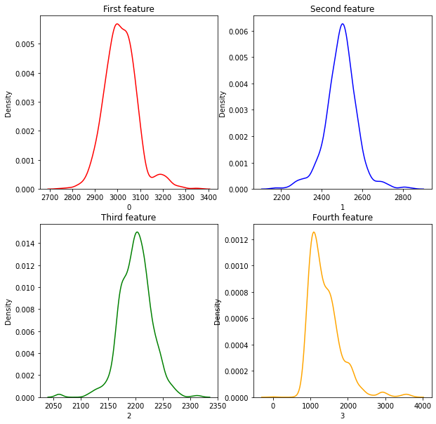

```python
# 3. Data analysis & visualisation: [5 Marks]
# A. Perform a detailed univariate Analysis with appropriate detailed comments after each analysis. [2 Marks]

plt.figure(figsize=(10,10))
plt.subplot(2,2,1)
sns.kdeplot(df_signal_new['0'], color = 'Red')
plt.title('First feature')

plt.subplot(2,2,2)
sns.kdeplot(df_signal_new['1'], color = 'Blue')
plt.title('Second feature')

plt.subplot(2,2,3)
sns.kdeplot(df_signal_new['2'], color = 'Green')
plt.title('Third feature')

plt.subplot(2,2,4)
sns.kdeplot(df_signal_new['3'], color = 'Orange')
plt.title('Fourth feature')
```

We see some skewness in fourth feature.

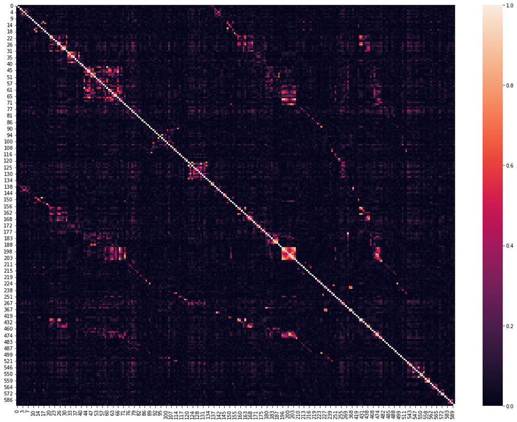

```python
# B. Perform bivariate and multivariate analysis with appropriate detailed comments after each analysis. [3 Marks]

plt.figure(figsize = (20,15))
sns.heatmap(abs(df_signal_new.corr()), vmin = 0, vmax = 1)
plt.show()
```

Lighter the cell, higher the correlation There is a near 100% multi-collinearity among a very few variables

```python
# 4. Data pre-processing: [10 Marks]
# A. Segregate predictors vs target attributes. [2 Marks]

X = df_signal_new.drop(['Pass/Fail'], axis=1)
y=df_signal_new['Pass/Fail']

print(df_signal_new.shape,X.shape,y.shape)
```

```
(1567, 248) (1567, 247) (1567,)
```

```python
# Perform train-test split and standardise the data or vice versa if required. [3 Marks]

from sklearn.model_selection import train_test_split

X_train, X_test, y_train, y_test = train_test_split(X,y, test_size = 0.2, random_state =2,stratify=y)
```

```python
print(X.shape,y.shape)
print(X_train.shape,y_train.shape)
print(X_test.shape,y_test.shape)
```

```
(1567, 247) (1567,)
(1253, 247) (1253,)
(314, 247) (314,)
```

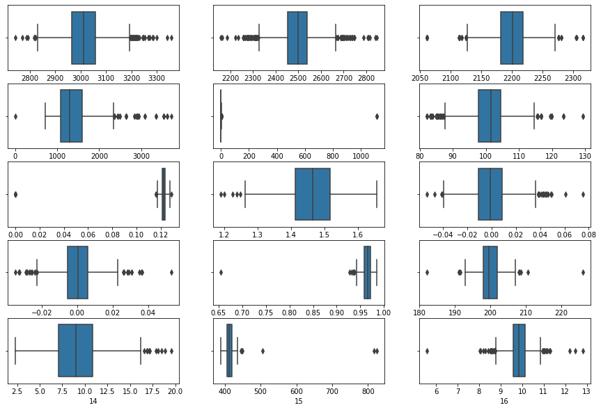

```python
# Check for outliers on train data for sample features

plt.figure(figsize=(15,10))
pos = 1
for i in X_train.columns:
    plt.subplot(5, 3, pos)
    sns.boxplot(X_train[i])
    if(pos == 15):
        break
    else:
        pos += 1
```

```python
# Remove outliers using IQR

for i in X_train.columns:
    q1, q2, q3 = X_train[i].quantile([0.25,0.5,0.75])
    IQR = q3 - q1
    a = X_train[i] > q3 + 1.5*IQR
    b = X_train[i] < q1 - 1.5*IQR
    X_train[i] = np.where(a | b, q2, X_train[i])
```

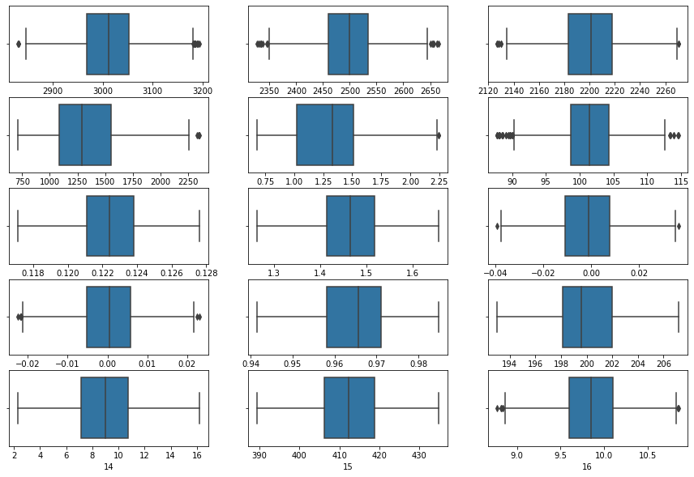

```python
# Check outliers again after clearing the outlier data

plt.figure(figsize=(15,10))
pos = 1
for i in X_train.columns:
    plt.subplot(5, 3, pos)
    sns.boxplot(X_train[i])
    if(pos == 15):
        break
    else:
        pos += 1
```

Far better, lets ignore the other outliers which might have been induced due to this outlier treatment.

```python
print(X_train.shape)
```

```
(1253, 247)
```

```python
# B. Check for target balancing and fix it if found imbalanced. [3 Marks]
pd.value_counts(y_train)
```

```
-1    1170
 1      83
Name: Pass/Fail, dtype: int64
```

```python
#!pip install imblearn
```

```python
from imblearn.over_sampling import SMOTE

X_train_resampled, y_train_resampled = SMOTE().fit_resample(X_train,y_train)
X_test_resampled, y_test_resampled = SMOTE().fit_resample(X_test,y_test)
```

```python
pd.value_counts(y_train_resampled)
```

```
-1    1170
 1    1170
Name: Pass/Fail, dtype: int64
```

```python
pd.value_counts(y_test_resampled)
```

```
-1    293
 1    293
Name: Pass/Fail, dtype: int64
```

Train and test dataset has been upsampled using SMOTE.

```python
# C. Perform train-test split and standardise the data or vice versa if required. [3 Marks]

# Already train-test split completed in the above steps. Standardization will be done as part of pipelline.
```

```python
# D. Check if the train and test data have similar statistical characteristics when compared with original data. [2 Marks]
df_signal_new.describe()
```

|  | 0 | 1 | 2 | 3 | 4 | 6 | 7 | 8 | 9 | 10 | ... | 570 | 571 | 572 | 573 | 582 | 583 | 586 | 587 | 589 | Pass/Fail |
| --- | --- | --- | --- | --- | --- | --- | --- | --- | --- | --- | --- | --- | --- | --- | --- | --- | --- | --- | --- | --- | --- |
| count | 1567.000000 | 1567.000000 | 1567.000000 | 1567.000000 | 1567.000000 | 1567.000000 | 1567.000000 | 1567.000000 | 1567.000000 | 1567.000000 | ... | 1567.000000 | 1567.000000 | 1567.000000 | 1567.000000 | 1567.000000 | 1567.000000 | 1567.000000 | 1567.000000 | 1567.000000 | 1567.000000 |
| mean | 3014.452896 | 2495.850231 | 2200.547318 | 1396.376627 | 4.197013 | 101.112908 | 0.121822 | 1.462862 | -0.000841 | 0.000146 | ... | 530.523623 | 2.101836 | 28.450165 | 0.345636 | 0.500096 | 0.015318 | 0.021458 | 0.016475 | 99.670066 | -0.867262 |
| std | 73.480613 | 80.227793 | 29.380932 | 439.712852 | 56.103066 | 6.209271 | 0.008936 | 0.073849 | 0.015107 | 0.009296 | ... | 17.499736 | 0.275112 | 86.304681 | 0.248478 | 0.003403 | 0.017174 | 0.012354 | 0.008805 | 93.861936 | 0.498010 |
| min | 2743.240000 | 2158.750000 | 2060.660000 | 0.000000 | 0.681500 | 82.131100 | 0.000000 | 1.191000 | -0.053400 | -0.034900 | ... | 317.196400 | 0.980200 | 3.540000 | 0.066700 | 0.477800 | 0.006000 | -0.016900 | 0.003200 | 0.000000 | -1.000000 |
| 25% | 2966.665000 | 2452.885000 | 2181.099950 | 1083.885800 | 1.017700 | 97.937800 | 0.121100 | 1.411250 | -0.010800 | -0.005600 | ... | 530.702700 | 1.982900 | 7.500000 | 0.242250 | 0.497900 | 0.011600 | 0.013450 | 0.010600 | 44.368600 | -1.000000 |
| 50% | 3011.840000 | 2498.910000 | 2200.955600 | 1287.353800 | 1.317100 | 101.492200 | 0.122400 | 1.461600 | -0.001300 | 0.000400 | ... | 532.398200 | 2.118600 | 8.650000 | 0.293400 | 0.500200 | 0.013800 | 0.020500 | 0.014800 | 72.023000 | -1.000000 |
| 75% | 3056.540000 | 2538.745000 | 2218.055500 | 1590.169900 | 1.529600 | 104.530000 | 0.123800 | 1.516850 | 0.008400 | 0.005900 | ... | 534.356400 | 2.290650 | 10.130000 | 0.366900 | 0.502350 | 0.016500 | 0.027600 | 0.020300 | 114.749700 | -1.000000 |
| max | 3356.350000 | 2846.440000 | 2315.266700 | 3715.041700 | 1114.536600 | 129.252200 | 0.128600 | 1.656400 | 0.074900 | 0.053000 | ... | 589.508200 | 2.739500 | 454.560000 | 2.196700 | 0.509800 | 0.476600 | 0.102800 | 0.079900 | 737.304800 | 1.000000 |

8 rows × 248 columns

```python
X_train_resampled.describe()
```

|  | 0 | 1 | 2 | 3 | 4 | 6 | 7 | 8 | 9 | 10 | ... | 565 | 570 | 571 | 572 | 573 | 582 | 583 | 586 | 587 | 589 |
| --- | --- | --- | --- | --- | --- | --- | --- | --- | --- | --- | --- | --- | --- | --- | --- | --- | --- | --- | --- | --- | --- |
| count | 2340.000000 | 2340.000000 | 2340.000000 | 2340.000000 | 2340.000000 | 2340.000000 | 2340.000000 | 2340.000000 | 2340.000000 | 2340.000000 | ... | 2340.000000 | 2340.000000 | 2340.000000 | 2340.000000 | 2340.000000 | 2340.000000 | 2340.000000 | 2340.000000 | 2340.000000 | 2340.000000 |
| mean | 3000.111403 | 2497.999293 | 2199.189597 | 1348.952355 | 1.307827 | 101.284456 | 0.122473 | 1.470480 | -0.002562 | 0.000109 | ... | 0.136143 | 532.703238 | 2.160717 | 8.719580 | 0.288355 | 0.500153 | 0.013901 | 0.020629 | 0.016303 | 82.072655 |
| std | 59.432384 | 53.914116 | 23.162067 | 299.892340 | 0.290753 | 4.165719 | 0.001625 | 0.061395 | 0.012788 | 0.007947 | ... | 0.045274 | 2.183152 | 0.188270 | 1.617930 | 0.079598 | 0.003178 | 0.002907 | 0.009373 | 0.006359 | 45.646033 |
| min | 2829.840000 | 2327.290000 | 2126.655500 | 711.025800 | 0.681500 | 87.741100 | 0.117100 | 1.263400 | -0.039300 | -0.022500 | ... | 0.022400 | 525.623600 | 1.555000 | 4.840000 | 0.066700 | 0.491500 | 0.006000 | -0.006000 | 0.003200 | 0.000000 |
| 25% | 2959.827408 | 2465.490000 | 2182.905861 | 1108.441115 | 1.114957 | 98.898325 | 0.121359 | 1.432300 | -0.010471 | -0.005198 | ... | 0.092866 | 531.302375 | 2.036461 | 7.620000 | 0.238811 | 0.498100 | 0.011700 | 0.014370 | 0.011456 | 50.627921 |
| 50% | 2996.790000 | 2499.350000 | 2198.731542 | 1291.127928 | 1.325700 | 101.492200 | 0.122400 | 1.470952 | -0.002187 | 0.000510 | ... | 0.142880 | 532.498313 | 2.163546 | 8.680000 | 0.290900 | 0.500100 | 0.013800 | 0.020302 | 0.015600 | 72.646900 |
| 75% | 3038.518664 | 2531.077500 | 2214.817498 | 1547.684204 | 1.480283 | 103.935797 | 0.123534 | 1.511114 | 0.005003 | 0.005700 | ... | 0.153863 | 534.056438 | 2.295676 | 9.811218 | 0.331700 | 0.502200 | 0.015682 | 0.026894 | 0.020337 | 102.493575 |
| max | 3193.530000 | 2666.040000 | 2270.255600 | 2347.909200 | 2.244900 | 114.585600 | 0.127600 | 1.656400 | 0.036200 | 0.023000 | ... | 0.284000 | 539.255400 | 2.739500 | 14.120000 | 0.555100 | 0.508800 | 0.024100 | 0.048400 | 0.035000 | 223.101800 |

8 rows × 247 columns

```python
X_test_resampled.describe()
```

|  | 0 | 1 | 2 | 3 | 4 | 6 | 7 | 8 | 9 | 10 | ... | 565 | 570 | 571 | 572 | 573 | 582 | 583 | 586 | 587 | 589 |
| --- | --- | --- | --- | --- | --- | --- | --- | --- | --- | --- | --- | --- | --- | --- | --- | --- | --- | --- | --- | --- | --- |
| count | 586.000000 | 586.000000 | 586.000000 | 586.000000 | 586.000000 | 586.000000 | 586.000000 | 586.000000 | 586.000000 | 586.000000 | ... | 586.000000 | 586.000000 | 586.000000 | 586.000000 | 586.000000 | 586.000000 | 586.000000 | 586.000000 | 586.000000 | 586.000000 |
| mean | 3020.451851 | 2492.434997 | 2201.396293 | 1331.937685 | 3.224059 | 101.478190 | 0.121495 | 1.455959 | -0.000174 | -0.000047 | ... | 0.155898 | 532.121518 | 2.131578 | 18.674125 | 0.333543 | 0.501045 | 0.015947 | 0.020721 | 0.016221 | 98.125353 |
| std | 71.688231 | 68.296819 | 24.298594 | 382.806874 | 45.988594 | 5.431932 | 0.007315 | 0.063639 | 0.012382 | 0.008937 | ... | 0.059457 | 6.324072 | 0.260587 | 63.589173 | 0.215094 | 0.003317 | 0.019727 | 0.011135 | 0.007481 | 81.509385 |
| min | 2825.670000 | 2187.670000 | 2060.660000 | 711.025800 | 0.721700 | 82.246700 | 0.000000 | 1.246200 | -0.035100 | -0.028000 | ... | 0.022600 | 458.846400 | 0.984700 | 3.540000 | 0.118800 | 0.477800 | 0.007100 | -0.016900 | 0.004900 | 0.000000 |
| 25% | 2970.143608 | 2448.608320 | 2186.026712 | 1082.732598 | 1.017700 | 99.131022 | 0.120755 | 1.412880 | -0.007226 | -0.005100 | ... | 0.112739 | 530.980900 | 2.013946 | 7.569886 | 0.236142 | 0.499200 | 0.011710 | 0.013863 | 0.011231 | 47.914171 |
| 50% | 3018.760000 | 2500.255000 | 2200.801415 | 1229.496400 | 1.311312 | 101.592616 | 0.121645 | 1.450749 | 0.000073 | 0.000400 | ... | 0.145610 | 532.351032 | 2.176098 | 8.391719 | 0.292149 | 0.501300 | 0.013800 | 0.020200 | 0.015021 | 78.059657 |
| 75% | 3058.918462 | 2537.248627 | 2215.054437 | 1502.922100 | 1.512300 | 103.463160 | 0.122900 | 1.493022 | 0.007153 | 0.005379 | ... | 0.190591 | 534.437811 | 2.324078 | 9.609588 | 0.372725 | 0.503499 | 0.016600 | 0.027000 | 0.019683 | 115.012800 |
| max | 3234.240000 | 2809.790000 | 2281.566700 | 3619.739700 | 1114.536600 | 129.252200 | 0.127600 | 1.648600 | 0.048900 | 0.039600 | ... | 0.359500 | 569.996400 | 2.739500 | 445.800000 | 2.196700 | 0.509800 | 0.471400 | 0.083100 | 0.079900 | 737.304800 |

8 rows × 247 columns

```python
# 5. Model training, testing and tuning: [20 Marks]
# A. Use any Supervised Learning technique to train a model. [2 Marks]
# B. Use cross validation techniques. [3 Marks]
# Hint: Use all CV techniques that you have learnt in the course.
# C. Apply hyper-parameter tuning techniques to get the best accuracy. [3 Marks]
# Suggestion: Use all possible hyper parameter combinations to extract the best accuracies.
# D. Use any other technique/method which can enhance the model performance. [4 Marks]
# Hint: Dimensionality reduction, attribute removal, standardisation/normalisation, target balancing etc.
# E. Display and explain the classification report in detail. [3 Marks]
# F. Apply the above steps for all possible models that you have learnt so far. [5 Marks]
```

```python
# A. Use any Supervised Learning technique to train a model. [2 Marks]

from sklearn.pipeline import Pipeline
from sklearn.preprocessing import StandardScaler
from sklearn.linear_model import LogisticRegression
from sklearn import metrics
from sklearn.metrics import average_precision_score, confusion_matrix, accuracy_score, classification_report
```

```python
# Create a LogisticRegression model using Pipeline
pipeline_LR = Pipeline([
    ('scaler',StandardScaler()),
    ('clf', LogisticRegression())
])

pipeline_LR.fit(X_train_resampled,y_train_resampled)

y_predict = pipeline_LR.predict(X_test)
train_model_score = pipeline_LR.score(X_train_resampled, y_train_resampled)
test_model_score  = pipeline_LR.score(X_test, y_test)
tn, fp, fn, tp = confusion_matrix(y_test,y_predict).ravel()
lr_recall = round(tp/(tp+fn), 3)
lr_precision = round(tp/(tp+fp), 3)
lr_specificity =round(tn/(tn+fp),3)

result = pd.DataFrame({'Model' : ['Logistic Regression'],
                        'Training Acc' : [train_model_score],
                        'Test Acc' : [test_model_score],
                        'Precision' : [lr_precision],
                        'True positive rate' : [lr_recall],
                        'True negative rate' : [lr_specificity],
                        'False positive rate' :  [1-lr_specificity]})
result
```

|  | Model | Training Acc | Test Acc | Precision | True positive rate | True negative rate | False positive rate |
| --- | --- | --- | --- | --- | --- | --- | --- |
| 0 | Logistic Regression | 0.979915 | 0.515924 | 0.088 | 0.667 | 0.505 | 0.495 |

```python
#Lets apply PCA there by reducing the dimensionality on Logistic Regression model

from sklearn.decomposition import PCA

pipeline_LR = Pipeline([
    ('scaler',StandardScaler()),
    ('pca',PCA(n_components=10)),
    ('clf', LogisticRegression())
])

pipeline_LR.fit(X_train_resampled,y_train_resampled)

y_predict = pipeline_LR.predict(X_test)
train_model_score = pipeline_LR.score(X_train_resampled, y_train_resampled)
test_model_score = pipeline_LR.score(X_test, y_test)
tn, fp, fn, tp = confusion_matrix(y_test,y_predict).ravel()
lr_recall = round(tp/(tp+fn), 3)
lr_precision = round(tp/(tp+fp), 3)
lr_specificity =round(tn/(tn+fp),3)

result.loc[1] = ['LogisticRegression(with PCA)', train_model_score, test_model_score,lr_precision,lr_recall,lr_specificity,1-lr_specificity]
result
```

|  | Model | Training Acc | Test Acc | Precision | True positive rate | True negative rate | False positive rate |
| --- | --- | --- | --- | --- | --- | --- | --- |
| 0 | Logistic Regression | 0.979915 | 0.515924 | 0.088 | 0.667 | 0.505 | 0.495 |
| 1 | LogisticRegression(with PCA) | 0.674786 | 0.554140 | 0.106 | 0.762 | 0.539 | 0.461 |

Looks Overfitting, has been addressed but accuracy is too low. Lets check the same using Random Forest Classifier.

```python
# Create a Random Forest Classifier model using Pipeline

from sklearn.ensemble import RandomForestClassifier

pipeline_RF = Pipeline([
    ('scaler',StandardScaler()),
    ('clf', RandomForestClassifier(n_estimators=50))
])

pipeline_RF.fit(X_train_resampled,y_train_resampled)

y_predict = pipeline_RF.predict(X_test)
train_model_score = pipeline_RF.score(X_train_resampled, y_train_resampled)
test_model_score = pipeline_RF.score(X_test, y_test)

tn, fp, fn, tp = confusion_matrix(y_test,y_predict).ravel()
lr_recall = round(tp/(tp+fn), 3)
lr_precision = round(tp/(tp+fp), 3)
lr_specificity =round(tn/(tn+fp),3)

result.loc[2] = ['Random Forest', train_model_score, test_model_score,lr_precision,lr_recall,lr_specificity,1-lr_specificity]
result
```

|  | Model | Training Acc | Test Acc | Precision | True positive rate | True negative rate | False positive rate |
| --- | --- | --- | --- | --- | --- | --- | --- |
| 0 | Logistic Regression | 0.979915 | 0.515924 | 0.088 | 0.667 | 0.505 | 0.495 |
| 1 | LogisticRegression(with PCA) | 0.674786 | 0.554140 | 0.106 | 0.762 | 0.539 | 0.461 |
| 2 | Random Forest | 1.000000 | 0.933121 | NaN | 0.000 | 1.000 | 0.000 |

```python
# Create a Random Forest Classifier with PCA model using Pipeline

pipeline_RF = Pipeline([
    ('scaler',StandardScaler()),
    ('pca',PCA(n_components=20)),
    ('clf', RandomForestClassifier(n_estimators=50))
])

pipeline_RF.fit(X_train_resampled,y_train_resampled)

y_predict = pipeline_RF.predict(X_test)
train_model_score = pipeline_RF.score(X_train_resampled, y_train_resampled)
test_model_score = pipeline_RF.score(X_test, y_test)

tn, fp, fn, tp = confusion_matrix(y_test,y_predict).ravel()
lr_recall = round(tp/(tp+fn), 3)
lr_precision = round(tp/(tp+fp), 3)
lr_specificity =round(tn/(tn+fp),3)

result.loc[3] = ['Random Forest(with PCA)', train_model_score, test_model_score,lr_precision,lr_recall,lr_specificity,1-lr_specificity]
result
```

|  | Model | Training Acc | Test Acc | Precision | True positive rate | True negative rate | False positive rate |
| --- | --- | --- | --- | --- | --- | --- | --- |
| 0 | Logistic Regression | 0.979915 | 0.515924 | 0.088 | 0.667 | 0.505 | 0.495 |
| 1 | LogisticRegression(with PCA) | 0.674786 | 0.554140 | 0.106 | 0.762 | 0.539 | 0.461 |
| 2 | Random Forest | 1.000000 | 0.933121 | NaN | 0.000 | 1.000 | 0.000 |
| 3 | Random Forest(with PCA) | 1.000000 | 0.796178 | 0.136 | 0.381 | 0.826 | 0.174 |

```python
#Lets check using SVC model

from sklearn.svm import SVC

pipeline_SVC = Pipeline([
    ('scaler',StandardScaler()),
    ('pca',PCA(n_components=20)),
    ('clf', SVC())
])

pipeline_SVC.fit(X_train_resampled,y_train_resampled)

y_predict = pipeline_SVC.predict(X_test)
train_model_score = pipeline_SVC.score(X_train_resampled, y_train_resampled)
test_model_score = pipeline_SVC.score(X_test, y_test)

tn, fp, fn, tp = confusion_matrix(y_test,y_predict).ravel()
lr_recall = round(tp/(tp+fn), 3)
lr_precision = round(tp/(tp+fp), 3)
lr_specificity =round(tn/(tn+fp),3)

result.loc[4] = ['SVC', train_model_score, test_model_score,lr_precision,lr_recall,lr_specificity,1-lr_specificity]
result
```

|  | Model | Training Acc | Test Acc | Precision | True positive rate | True negative rate | False positive rate |
| --- | --- | --- | --- | --- | --- | --- | --- |
| 0 | Logistic Regression | 0.979915 | 0.515924 | 0.088 | 0.667 | 0.505 | 0.495 |
| 1 | LogisticRegression(with PCA) | 0.674786 | 0.554140 | 0.106 | 0.762 | 0.539 | 0.461 |
| 2 | Random Forest | 1.000000 | 0.933121 | NaN | 0.000 | 1.000 | 0.000 |
| 3 | Random Forest(with PCA) | 1.000000 | 0.796178 | 0.136 | 0.381 | 0.826 | 0.174 |
| 4 | SVC | 0.979915 | 0.573248 | 0.081 | 0.524 | 0.577 | 0.423 |

```python
# Lets check using KNN model

from sklearn.neighbors import KNeighborsClassifier


pipeline_KNN = Pipeline([
    ('scaler',StandardScaler()),
    ('pca',PCA(n_components=20)),
    ('clf', KNeighborsClassifier(n_neighbors=2))
])

pipeline_KNN.fit(X_train_resampled,y_train_resampled)

y_predict = pipeline_KNN.predict(X_test)
train_model_score = pipeline_KNN.score(X_train_resampled, y_train_resampled)
test_model_score = pipeline_KNN.score(X_test, y_test)

tn, fp, fn, tp = confusion_matrix(y_test,y_predict).ravel()
lr_recall = round(tp/(tp+fn), 3)
lr_precision = round(tp/(tp+fp), 3)
lr_specificity =round(tn/(tn+fp),3)

result.loc[5] = ['KNN', train_model_score, test_model_score,lr_precision,lr_recall,lr_specificity,1-lr_specificity]
result
```

|  | Model | Training Acc | Test Acc | Precision | True positive rate | True negative rate | False positive rate |
| --- | --- | --- | --- | --- | --- | --- | --- |
| 0 | Logistic Regression | 0.979915 | 0.515924 | 0.088 | 0.667 | 0.505 | 0.495 |
| 1 | LogisticRegression(with PCA) | 0.674786 | 0.554140 | 0.106 | 0.762 | 0.539 | 0.461 |
| 2 | Random Forest | 1.000000 | 0.933121 | NaN | 0.000 | 1.000 | 0.000 |
| 3 | Random Forest(with PCA) | 1.000000 | 0.796178 | 0.136 | 0.381 | 0.826 | 0.174 |
| 4 | SVC | 0.979915 | 0.573248 | 0.081 | 0.524 | 0.577 | 0.423 |
| 5 | KNN | 0.997436 | 0.859873 | 0.171 | 0.286 | 0.901 | 0.099 |

```python
#Lets check Gradient Boosting

from sklearn.ensemble import GradientBoostingClassifier

pipeline_GB = Pipeline([
    ('scaler',StandardScaler()),
    ('pca',PCA(n_components=20)),
    ('clf', GradientBoostingClassifier())
])

pipeline_GB.fit(X_train_resampled,y_train_resampled)

y_predict = pipeline_GB.predict(X_test)
train_model_score = pipeline_GB.score(X_train_resampled, y_train_resampled)
test_model_score = pipeline_GB.score(X_test, y_test)

tn, fp, fn, tp = confusion_matrix(y_test,y_predict).ravel()
lr_recall = round(tp/(tp+fn), 3)
lr_precision = round(tp/(tp+fp), 3)
lr_specificity =round(tn/(tn+fp),3)

result.loc[6] = ['Gradient Boosting', train_model_score, test_model_score,lr_precision,lr_recall,lr_specificity,1-lr_specificity]
result
```

|  | Model | Training Acc | Test Acc | Precision | True positive rate | True negative rate | False positive rate |
| --- | --- | --- | --- | --- | --- | --- | --- |
| 0 | Logistic Regression | 0.979915 | 0.515924 | 0.088 | 0.667 | 0.505 | 0.495 |
| 1 | LogisticRegression(with PCA) | 0.674786 | 0.554140 | 0.106 | 0.762 | 0.539 | 0.461 |
| 2 | Random Forest | 1.000000 | 0.933121 | NaN | 0.000 | 1.000 | 0.000 |
| 3 | Random Forest(with PCA) | 1.000000 | 0.796178 | 0.136 | 0.381 | 0.826 | 0.174 |
| 4 | SVC | 0.979915 | 0.573248 | 0.081 | 0.524 | 0.577 | 0.423 |
| 5 | KNN | 0.997436 | 0.859873 | 0.171 | 0.286 | 0.901 | 0.099 |
| 6 | Gradient Boosting | 0.943590 | 0.627389 | 0.119 | 0.714 | 0.621 | 0.379 |

```python
# B. Use cross validation techniques using Random search Grid. [3 Marks]
# Hint: Use all CV techniques that you have learnt in the course.

lrcl =  LogisticRegression()
knncl =  KNeighborsClassifier()
svcl= SVC()
rfcl =  RandomForestClassifier()

for clf, label in zip([lrcl ,knncl, svcl, rfcl],
    ['lrcl' ,'knncl', 'svcl','rfcl']):
    print("model name: " , label)
    print("\n model_hyperparameters \n" , clf.get_params() )
```

[output not shown]

```python
# Applying Randomized Search for Logistic Regression
from sklearn.model_selection import KFold
from sklearn.model_selection import cross_val_score
from sklearn.model_selection import RandomizedSearchCV
from scipy.stats import randint as sp_randint

# specify parameters and distributions to sample from
LR_param_dist = {"C": sp_randint(1, 6),
              "penalty": ["l1", "l2" ],
                }

# run randomized search
samples = 5 # number of random samples
LR_randomCV = RandomizedSearchCV(lrcl, param_distributions=LR_param_dist, n_iter=samples,cv=3)

LR_randomCV.fit(X_train_resampled, y_train_resampled)
y_pred = LR_randomCV.predict(X_test)

train_model_score = LR_randomCV.best_score_
test_model_score = LR_randomCV.score(X_test,y_test)

print('Best Params for Logistic Rgression ',LR_randomCV.best_params_)
print('\n')

tn, fp, fn, tp = confusion_matrix(y_test,y_predict).ravel()
lr_recall = round(tp/(tp+fn), 3)
lr_precision = round(tp/(tp+fp), 3)
lr_specificity =round(tn/(tn+fp),3)

result.loc[7] = ['LogisticRegression Hypertuning', train_model_score, test_model_score,lr_precision,lr_recall,lr_specificity,1-lr_specificity]
result
```

```
Best Params for Logistic Rgression  {'C': 4, 'penalty': 'l2'}
```

[output not shown]

```python
# Applying Randomized Search for KNN

# specify parameters and distributions to sample from
KNN_param_dist = {"n_neighbors": sp_randint(1, 6),
                 "leaf_size": sp_randint(25, 35),
                }

# run randomized search
samples = 5  # number of random samples
KNN_randomCV = RandomizedSearchCV(knncl, param_distributions=KNN_param_dist, n_iter=samples,cv=3)

KNN_randomCV.fit(X_train_resampled, y_train_resampled)
y_pred=KNN_randomCV.predict(X_test)

train_model_score = KNN_randomCV.best_score_
test_model_score = KNN_randomCV.score(X_test,y_test)

print('Best Params for KNN ',KNN_randomCV.best_params_)
print('\n')

tn, fp, fn, tp = confusion_matrix(y_test,y_predict).ravel()
lr_recall = round(tp/(tp+fn), 3)
lr_precision = round(tp/(tp+fp), 3)
lr_specificity =round(tn/(tn+fp),3)

result.loc[8] = ['KNN Hypertuning', train_model_score, test_model_score,lr_precision,lr_recall,lr_specificity,1-lr_specificity]
result
```

```
Best Params for KNN  {'leaf_size': 27, 'n_neighbors': 2}
```

[output not shown]

```python
# Applying Randomized Search for RandomForest
from sklearn.model_selection import KFold
from sklearn.model_selection import cross_val_score
from sklearn.model_selection import RandomizedSearchCV
from scipy.stats import randint as sp_randint

# build a classifier
clf = RandomForestClassifier(n_estimators=50)

# specify parameters and distributions to sample from
RF_param_dist = {"max_depth": [3, None],
              "max_features": sp_randint(5, 11),
              "min_samples_split": sp_randint(5, 11),
              "min_samples_leaf": sp_randint(5, 11),
              "criterion": ["gini", "entropy"]}

# run randomized search
samples = 5  # number of random samples
RF_randomCV = RandomizedSearchCV(clf, param_distributions=RF_param_dist, n_iter=samples,cv=3)

RF_randomCV.fit(X_train_resampled, y_train_resampled)
y_pred=RF_randomCV.predict(X_test)

train_model_score = RF_randomCV.best_score_
test_model_score = RF_randomCV.score(X_test,y_test)

print('Best Params for Random Forest ',RF_randomCV.best_params_)
print('\n')

tn, fp, fn, tp = confusion_matrix(y_test,y_predict).ravel()
lr_recall = round(tp/(tp+fn), 3)
lr_precision = round(tp/(tp+fp), 3)
lr_specificity =round(tn/(tn+fp),3)

result.loc[9] = ['RandomForest Hypertuning', train_model_score, test_model_score,lr_precision,lr_recall,lr_specificity,1-lr_specificity]
result
```

```
Best Params for Random Forest  {'criterion': 'gini', 'max_depth': None, 'max_features': 5, 'min_samples_leaf': 7, 'min_samples_split': 10}
```

|  | Model | Training Acc | Test Acc | Precision | True positive rate | True negative rate | False positive rate |
| --- | --- | --- | --- | --- | --- | --- | --- |
| 0 | Logistic Regression | 0.979915 | 0.515924 | 0.088 | 0.667 | 0.505 | 0.495 |
| 1 | LogisticRegression(with PCA) | 0.674786 | 0.554140 | 0.106 | 0.762 | 0.539 | 0.461 |
| 2 | Random Forest | 1.000000 | 0.933121 | NaN | 0.000 | 1.000 | 0.000 |
| 3 | Random Forest(with PCA) | 1.000000 | 0.796178 | 0.136 | 0.381 | 0.826 | 0.174 |
| 4 | SVC | 0.979915 | 0.573248 | 0.081 | 0.524 | 0.577 | 0.423 |
| 5 | KNN | 0.997436 | 0.859873 | 0.171 | 0.286 | 0.901 | 0.099 |
| 6 | Gradient Boosting | 0.943590 | 0.627389 | 0.119 | 0.714 | 0.621 | 0.379 |
| 7 | LogisticRegression Hypertuning | 0.679060 | 0.598726 | 0.119 | 0.714 | 0.621 | 0.379 |
| 8 | KNN Hypertuning | 0.876068 | 0.818471 | 0.119 | 0.714 | 0.621 | 0.379 |
| 9 | RandomForest Hypertuning | 0.977350 | 0.929936 | 0.119 | 0.714 | 0.621 | 0.379 |

```python
#Classification Report

from sklearn.metrics import classification_report

print(classification_report(y_test, y_pred))
```

```
              precision    recall  f1-score   support

          -1       0.93      1.00      0.96       293
           1       0.00      0.00      0.00        21

    accuracy                           0.93       314
   macro avg       0.47      0.50      0.48       314
weighted avg       0.87      0.93      0.90       314
```

```python
#Saving the Prject using Pickle
```

```python
import pickle

#Save the model
FMT_model=pickle.dumps(RF_randomCV)
```

```python
#Load the model

load_FMT_model=pickle.loads(FMT_model)
```

```python
# Lets check it by predicting
load_FMT_model.predict(X_test)
load_FMT_model.score(X_test,y_test)
```

```
0.9299363057324841
```

# Conclusion

The provided dataset had 1567 rows and 592 features. After treating the missing values we have reduced the features to 560 features After removing the zero standard deviation features are reduced to 444. After removing the 90% correlated columns the features are reduced to 249. Target class imbalance was addressed using SMOTE method

Model Improvization: We have trainied the model using LogisticRegression, RandomForest, KNN, SVC and Gradient Boosting. But most of which resulted in overfitting. Hence hypertuned the models using randomized search where Random forest tuned out to yield 93% accuracy.